# Bestemmelse af permeabilitetskoefficienten (P<sub>app</sub>) over Caco-2 cellemonolag

Udgivet

16. oktober 2026

# Introduktion

Dette dokument guider dig igennem dataanalysen for et **Caco-2 permeabilitetsassay**. Caco-2-cellelaget er en udbredt *in vitro*-model for lægemiddelstoftransport over mave-tarm epitelet og bruges til at estimere oral absorption.

I dette forsøg tilsættes lægemiddelstofkandidaten **X** til den **apikale (donor)** side, og koncentrationen på den **basolaterale (receiver)** side måles over tid. Fra disse data vil vi:

1. Indlæse de eksperimentelle data
2. Beregne den kumulative mængde af **X**, der er transporteret, med korrektion for prøveudtagning
3. Kontrollere om sink-betingelser var opretholdt
4. Beregne flux ved hvert tidsinterval
5. Plotte kumulativ transport mod tid og identificere steady-state-området
6. Tilpasse en lineær model til steady-state-data for at bestemme flux og lag-tid
7. Beregne permeabilitetskoefficienten *P<sub>app</sub>*

## Relevans og perspektiver

Denne dataanalyse bygger bl.a. på lineær regression, samt andre relevante fremgangsmåder I vil møde gentagne gange:

- I har tidligere arbejdet med en tilsvarende fremgangsmåde ved analyse af dissolutionforsøg (FA503)
- Labøvelse 2 (*In vitro afgivelse af nikotinsyreestre fra forskellige salvegrundlag*) har samme analytiske tilgang og R-arbejdsgang, men regression mod √t (Higuchi-kinetik)
- Labøvelse 3 (*Stabilitet af acetylsalicylsyre*) bygger på lineær regression på ln-transformerede data til 1. ordens kinetik og Arrhenius-plot

Det R-script I arbejder med her er med andre ord en skabelon for kvantitativ dataanalyse, som I vil genbruge i flere sammenhænge.

Derudover er *P<sub>app</sub>* en central parameter i lægemiddeludvikling og -klassificering:

- Caco-2-modellen er industristandarden for *in vitro*-permeabilitetsmålinger og anvendes rutinemæssigt som tidligt screeningsværktøj i både akademisk forskning og den farmaceutiske industri.

# 1 Baggrund

Transportforsøg foregår i brønde med celler udsået på en permeabel membran, se Figur 1.

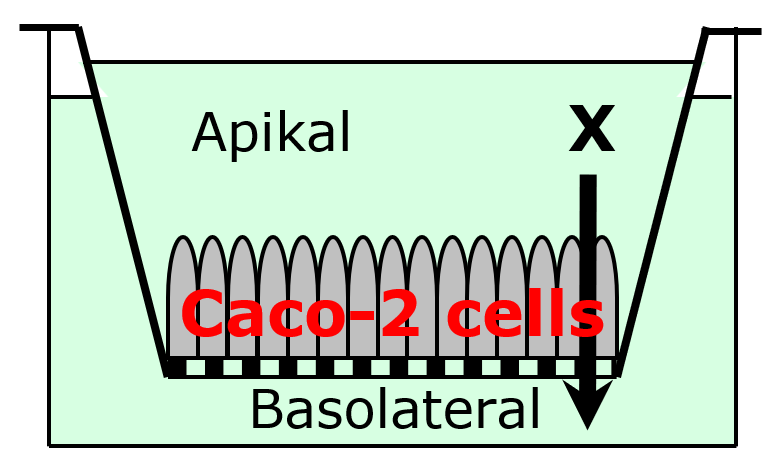

Figur 1: Transwellsystem med Caco-2 celler. Øverste kammer er apikalt og nederste basolateralt. Apikal volumen = 0,5 ml, Basolateral volumen = 1,0 ml. Prøvevolumen, receiver prøve (basolateral) = 100 μl. Prøvevolumen, donor opløsning (apikal) = 20 μl. Areal = 1,12 cm<sup>2</sup>.

Apikal til basolateral (ækvivalent til lumen-blod) flux, J<sup>l-b</sup>, for en lægemiddelstofkandidat, **X**, er undersøgt ved transportstudier over 21 dage gamle Caco-2 celle monolag, som vist i Figur 1. **X** er blevet tilsat til den apikale (luminale) side i en koncentration på **50 mM**. Der er udtaget prøver på acceptor (receiver) siden hvert 15 min, og mængden af **X** er blevet bestemt. Til start og slut er der udtaget en prøve fra donoropløsningen som er blevet kvantificeret for indholdet af **X** (50 mM ved start, 48 mM ved slut). Data kan findes i filen `caco2_data.xlsx`.

**Eksperimentelle parametre:** Forsøget er lavet med omrøring. Apikal volumen = 0,5 ml. Basolateral volumen = 1,0 ml. Prøve volumen, receiver opløsning (basolateral) = 100 μl. Prøve volumen, donor opløsning (apikal) = 20 μl. Areal af Caco-2 cellemonolag = 1,12 cm<sup>2</sup>. Donorprøver er ikke erstattet med ny opløsning, men prøver udtaget på receiver siden er blevet erstattet med frisk buffer som ikke indeholder **X**, hvormed volumen i systemet er konstant over forsøget.

# 2 Opsætning

## 2.1 Indlæs relevante pakker

```r
library(tidyverse)
library(readxl)
```

> Husk at installere pakker med `install.packages()`, hvis dette ikke tidligere er gjort.

## 2.2 Eksperimentelle parametre

Definer de eksperimentelle parametre.

```r
V_d   <- ___    # Donor (apikal) volumen, mL
V_r   <- ___    # Receiver (basolateral) volumen, mL
V_s   <- ___    # Prøvevolumen udtaget fra receiver ved hvert tidspunkt, mL
C_0   <- ___    # Initial donorkoncentration, mM
areal <- ___    # Overfladeareal, cm²
```

## 2.3 Indlæs data

Gem excel-filen `caco2_data.xlsx` med data i din projektmappe. Filen skal have to kolonner:

- `tid_min` — prøvetagningstidspunkt i minutter
- `C_mM` — målt koncentration i receiver-kammeret på det pågældende tidspunkt (mM)

Importér derefter data i *R* ved brug af `read_excel()` (se evt. mere [her](https://readxl.tidyverse.org/)).

```r
data <- ___ # importer data
```

> Tjek at data er indlæst korrekt.

# 3 Databehandling

## 3.1 Mængde i hver receiver-prøve

Ved hvert tidspunkt udtages en prøve med volumen $V_s$ fra receiver-kammeret. Brug `mutate()` funktionen til at oprette en kolonne (`n_sample_nmol`) i dit dataframe, der udregner mængden af **X** i hver prøve (i nmol). Husk, at `mutate()` funktionen bruges ved at referere til kolonnenavne og variabelnavne, for automatisk at udregne værdier for hver række (læs evt. mere om `mutate()`: [her](https://cpdse-edux.github.io/R_documentation/functions/mutate.html) eller [her](https://dplyr.tidyverse.org/reference/mutate.html)).

```r
data <- data %>%
  mutate(
    n_sample_nmol = ____   # nmol af X i de udtagne prøver
  )
```

## 3.2 Kumulativ transporteret mængde — korrektion for prøveudtagning

For at bestemme den totale mængde af **X**, som er transporteret over Caco-2 cellelaget, skal der tages højde for de udtagne prøver, som efterfølgende erstattes af ren buffer. Dvs. at volumenet i receiverkammeret (`V_r`) forbliver konstant, men en større og større mængde af **X** bliver fjernet fra systemet i form af de udtagne prøver. Altså udgøres den totale mængde af transporteret **X**, til et givent tidspunkt, af både mængden af **X** i receiverkammeret + den kumulative sum af **X** i de forrige prøver:

$$n_{total,t} = C_{t} \cdot V_r + \sum_{i<t} n_{sample,i}$$

Hvor $C_t$ er koncentrationen af **X** i receiverkammeret til tiden $t$, $V_r$ er volumenet i receiverkammeret, og $n_{sample,i}$ er mængden af X i prøverne udtaget før tiden $t$. Brug igen `mutate()` til at udregne disse værdier for alle tidspunkter i en ny kolonne `n_total_nmol`. Det er en fordel at bruge `cumsum()` og `lag()` funktionen (se evt. dissolution databehandling fra FA503). Husk at omregne til nmol!

```r
# Tilføj en ny kolonne (n_total_nmol) til dit dataframe vha. mutate, med den totale mængde X transporteret til hvert tidspunkt
```

## 3.3 Flux ved hvert tidsinterval

Fluxen $J$ i hvert interval kan beregnes som forskellen af mængden af **X** transporteret divideret med tidsintervallet og arealet:

$$J_i = \frac{n_{total,i} - n_{total,i-1}}{(t_i - t_{i-1}) \cdot A} \quad \left[\frac{\text{nmol}}{\text{min} \cdot \text{cm}^2 }\right]$$

Tilføj endnu en kolonne (`flux`) til dit dataframe, hvor du udregner fluxen (i $\frac{\text{nmol}}{\text{min} \cdot \text{cm}^2}$) i hvert interval vha. `mutate()`. Husk igen, at `lag()` funktionen kan bruges til at returnere værdien fra den foregående række i en kolonne (f.eks. giver `lag(n_total_nmol)` $n_{total,i-1}$).

```r
# Skriv din egen kode til at beregne flux som en ny kolonne vha. mutate
```

# 4 Kontrol af sink-conditions

Bestem den %-del af **X**, som er blevet transporteret over Caco-2 cellelaget ved slutningen af forsøget.

**Hint**: I `tidyverse` pakken kan du bruge `last()` funktionen til at få den sidste værdi i en kolonne/vektor.

```r
pct_transporteret  <- ____   # procent X transporteret ved slut
```

> **Opgave:** Hvor stor en %-del af **X** er transporteret? Lever dette op til *sink conditions*?

# 5 Plot: Kumulativ transport mod tid

Plot den totale mængde **X** transporteret som funktion af tid.

**Hint**: brug `ggplot()` og `geom_point()`.

```r
# udfyld blanke og tilføj egen kode for evt. at tilføje aksetitler etc.
ggplot(____, aes(x = ____, y = ____)) +
_____
```

> **Opgave:** Inspicér plottet. Ved hvilket tidspunkt bliver kurven tilnærmelsesvis lineær? Vælg de tidspunkter, der repræsenterer steady-state-transport, og brug dem i næste afsnit.

# 6 Steady-state-analyse

## 6.1 Udvælg steady-state-data

Baseret på visuel inspektion filtreres data til kun at inkludere steady-state-området og gemmes som en ny dataframe `ss_data`. Funktionen `filter()` kan bruges til at udvælge rækker i en dataframe, der opfylder en bestemt betingelse (se evt. mere [her](https://dplyr.tidyverse.org/reference/filter.html)).

```r
ss_data <- data %>%
  filter(____)
```

Inspicer evt. den nye dataframe for at sikre, at de rigtige rækker er blevet filtreret.

## 6.2 Lineær regression

Vi bruger `lm()` til at tilpasse en ret linje til steady-state-data. Funktionen tager en **formel** på formen `y ~ x` samt et `data`-argument (læs mere [her](https://www.geeksforgeeks.org/r-language/how-to-use-lm-function-in-r-to-fit-linear-models/)). I `lm()` bruges `~` til at adskille den variabel, du vil forudsige (afhængige variabel), fra den/de variabler, du bruger til at forudsige den med (uafhængige variabel). Kort sagt betyder `~`: “er en funktion af”.

```r
fit <- lm(____ ~ ____, data = _____)
summary(fit)
```

`summary()` giver et overblik over fittet (bl.a. skæring, hældning og $R^2$)

Udtræk skæringspunkt og hældning med `coef()`:

- `coef(fit)[[1]]` — **skæringspunktet** (nmol)
- `coef(fit)[[2]]` — **hældningen** (nmol/min)

```r
skæring <- ____
hældning <- ____
```

For at visualisere regressionslinjen kan følgende kode tilføjes til ggplottet ovenfor (husk at nye lag kan tilføjes i `ggplot()` ved brug af `+`).

```r
geom_abline(intercept = skæring, slope = hældning)
```

## 6.3 Steady-state-flux

Beregn fluxen ud fra hældningen på kurven under steady state og overfladearealet:

```r
J_ss <- ____    # nmol/(cm²·min)
```

> **Opgave:** Hvad er steady state fluxen?

## 6.4 Lag-tid

Lag-tiden er x-akseskæringen for regressionslinjen (hvor den ekstrapolerede linje krydser $n_{total} = 0$). Dette kan først vurderes visuelt og derefter udregnes ud fra regressionslinjen.

```r
t_lag <- ____ # min
```

> **Opgave:** Hvad er lag-tiden (visuelt og udregnet)?

# 7 Beregning af P<sub>app</sub>

Brug din viden om sammenhængen mellem flux, permeabilitet ($P_{app}$) og koncentrationsgradient til at udregne $P_{app}$ og vær omhyggelig med enhedsomregninger (enhed skal være i cm/s). Du skal kunne redegøre for alle enhedsomregninger. Når du har udledt formlen, implementér den i R:

```r
# Dine enhedsomregninger her
C0_nmol_per_cm3 <- ____   # omregn C0 fra mM til nmol/cm³
J_per_s <- ____           # omregn J_ss fra nmol/(cm²·min) til nmol/(cm²·s)
Papp <- ____              # cm/s
```

> **Opgave:** Hvad er P<sub>app</sub>?

# 8 Opsummering

Følgende kode kan bruges til at give en opsummering af de bestemte værdier, når de alle er defineret i R.

```r
cat("=== Resultater ===
% transporteret (sink-kontrol):  ", signif(pct_transporteret, 3), "%
Steady-state-flux:               ", signif(J_ss, 3), "nmol/(cm²·min)
Lag-tid:                         ", signif(t_lag, 3), "min
P_app:                           ", signif(Papp,  3), "cm/s")
```